# IODS course project

### 4) Variable exploration and analysis

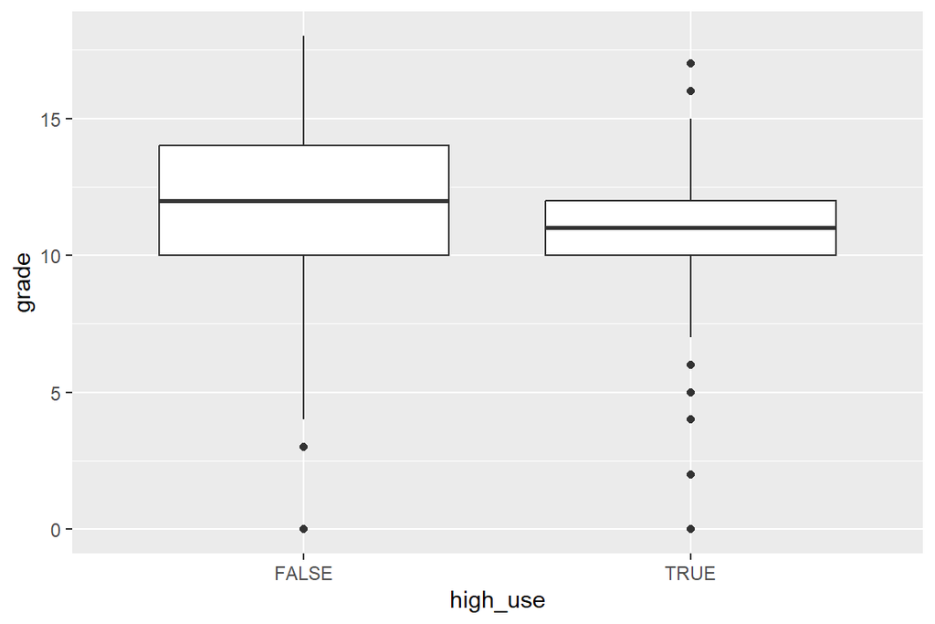

```r
# initialize a plot of high_use and G3
g1 <- ggplot(stu2, aes(x = high_use, y = G3))

# define the plot as a boxplot and draw it
g1 + geom_boxplot() + ylab("grade")
```

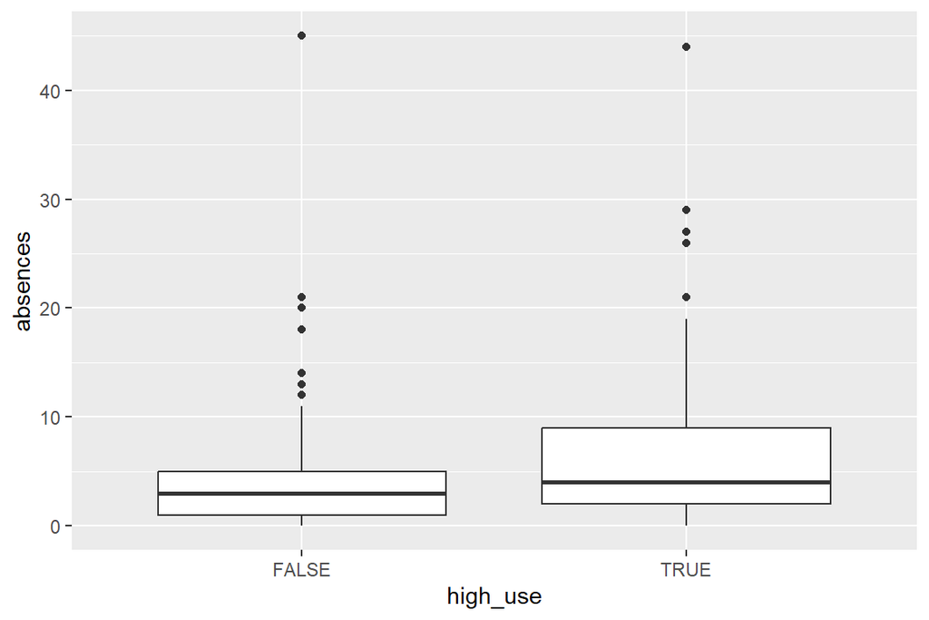

```r
# initialize a plot of absences and high_use
g2 <- ggplot(stu2, aes(x = high_use, y = absences))

# define the plot as a boxplot and draw it
g2 + geom_boxplot() + ylab("absences")
```

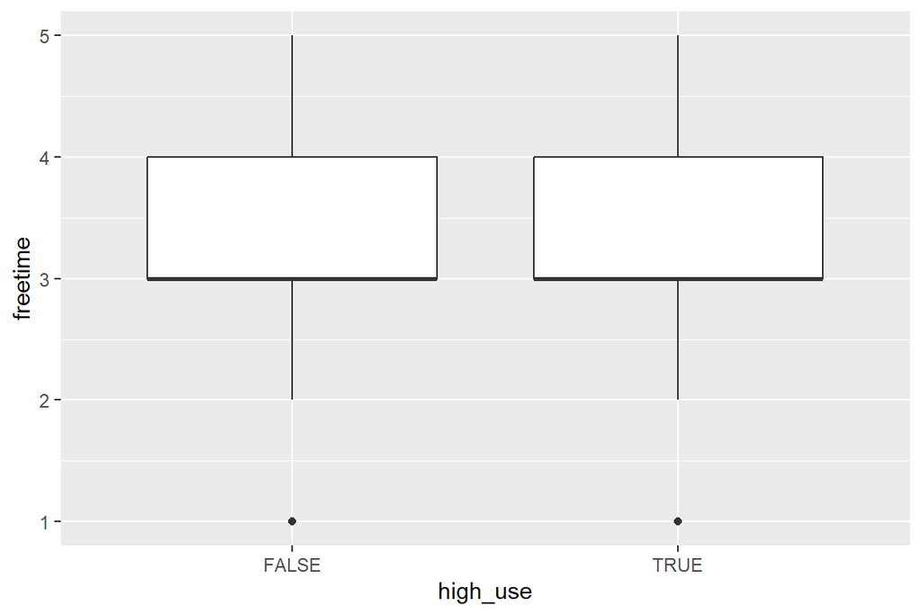

```r
g3 <- ggplot(stu2, aes(x = high_use, y = freetime))
g3 + geom_boxplot() + ylab("freetime")
```

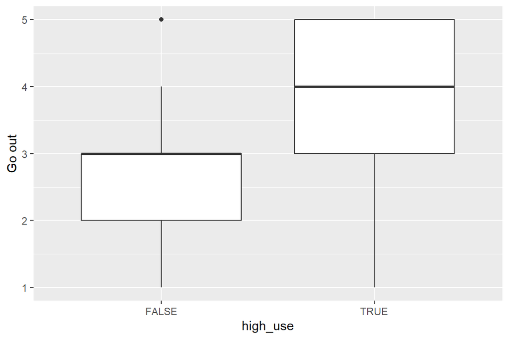

```r
g4 <- ggplot(stu2, aes(x= high_use, y = goout))
g4 + geom_boxplot() + ylab("Go out")
```

I would say that my hypothses were right except for freetime which does not seem to have a large effect.

### 5) Logistic regression

```r
library(dplyr)

# create log. regr. model with glm()
m <- glm(high_use ~ absences + G3 + freetime + goout, data = stu2, family = "binomial")

# print out a summary of the model
summary(m)
```

```
##
## Call:
## glm(formula = high_use ~ absences + G3 + freetime + goout, family = "binomial",
##     data = stu2)
##
## Deviance Residuals:
##     Min       1Q   Median       3Q      Max
## -1.8991  -0.7493  -0.5454   0.9562   2.3156
##
## Coefficients:
##             Estimate Std. Error z value Pr(>|z|)
## (Intercept) -3.44456    0.74167  -4.644 3.41e-06 ***
## absences     0.07621    0.02232   3.415 0.000639 ***
## G3          -0.04741    0.03895  -1.217 0.223534
## freetime     0.18074    0.13765   1.313 0.189149
## goout        0.66087    0.12345   5.353 8.63e-08 ***
## ---
## Signif. codes:  0 '***' 0.001 '**' 0.01 '*' 0.05 '.' 0.1 ' ' 1
##
## (Dispersion parameter for binomial family taken to be 1)
##
##     Null deviance: 452.04  on 369  degrees of freedom
## Residual deviance: 387.11  on 365  degrees of freedom
## AIC: 397.11
##
## Number of Fisher Scoring iterations: 4
```

**Summary:** According to the fitted model, variables absences and going out have a statistically significant relationship with high use of alcohol. Furthermore, results indicate that the higher value in absences or goout, the more likely it is for a student to be a high user.

Other two variables (freetime and grade) do not have a statistically significant relationship with high_use.

```r
# model coefficients
coef(m)
```

```
## (Intercept)    absences          G3    freetime       goout
## -3.44455619  0.07621284 -0.04740708  0.18074250  0.66086856
```

```r
# compute odds ratios
OR <- coef(m) %>% exp

# compute confidence intervals
CI <- confint(m) %>% exp
# print out the odds ratios with their confidence intervals
cbind(OR, CI)
```

```
##                     OR       2.5 %    97.5 %
## (Intercept) 0.03191892 0.007107958 0.1310842
## absences    1.07919224 1.034335455 1.1301965
## G3          0.95369908 0.883428225 1.0296400
## freetime    1.19810663 0.915713983 1.5731307
## goout       1.93647355 1.529257163 2.4840232
```

Shortly, my hypothesis in the begin was largely accurate. However, I was not that precise with them (I did not consider if some variable will prove statistically significant)

### 6) Cross tabulation with statistically significant variables

```r
library(dplyr)
# Create model with variables with significant relationship with high_use
stu3 <- select(stu2, high_use, absences, goout)
m2 <- glm(high_use ~ absences + goout, data = stu3, family = "binomial")

# predict probability of high use
probabilities <- predict(m2, type="response")

stu3 <- stu3 %>%
  mutate(probability = probabilities) %>%
  mutate(prediction = probability > .5)

# cross tabulation
table(high_use = stu3$high_use, prediction = stu3$prediction)
```

```
##         prediction
## high_use FALSE TRUE
##    FALSE   236   23
##    TRUE     65   46
```

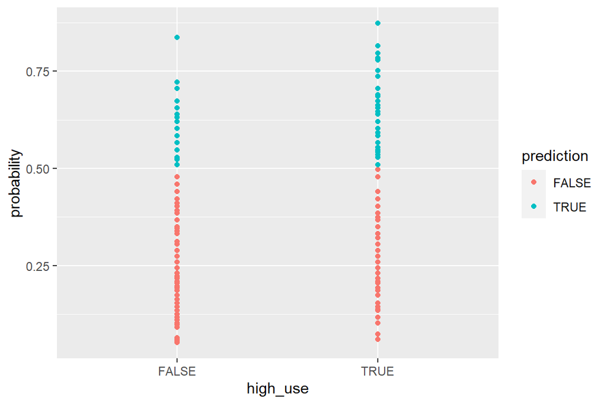

```r
# initialize a plot of 'high_use' versus 'probability' in 'alc'
g <- ggplot(stu3, aes(x = high_use, y = probability))


# define the geom as points and draw the plot
g + geom_point(aes(col=prediction))
```

```r
table(high_use = stu3$high_use, prediction = stu3$prediction) %>% prop.table %>% addmargins
```

```
##         prediction
## high_use      FALSE       TRUE        Sum
##    FALSE 0.63783784 0.06216216 0.70000000
##    TRUE  0.17567568 0.12432432 0.30000000
##    Sum   0.81351351 0.18648649 1.00000000
```

```r
# define a loss function (mean prediction error)
loss_func <- function(class, prob) {
  n_wrong <- abs(class - prob) > 0.5
  mean(n_wrong)
}


# This is the average number of wrong predictions

loss_func(class = stu3$high_use, prob = stu3$prediction)
```

```
## [1] 0.2378378
```

# Dimensionality reduction

### THE DATA

```r
date()
```

```
## [1] "Mon Dec 12 14:27:38 2022"
```

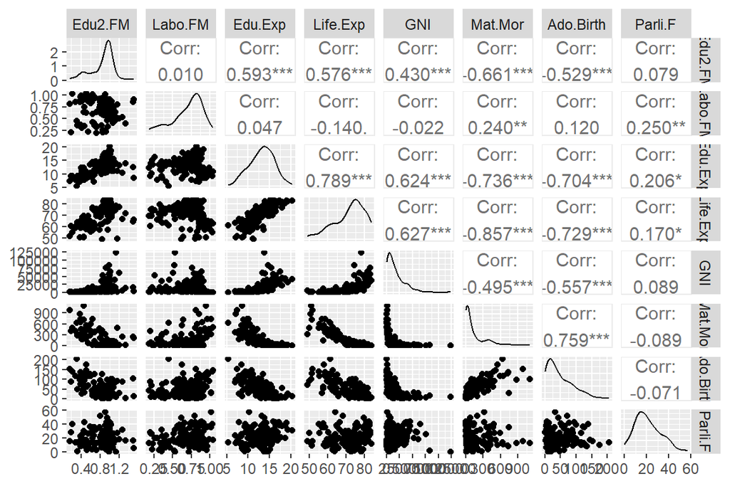

```r
library(GGally)
library(dplyr)
library(DT)
library(finalfit)

human <- read.table("https://raw.githubusercontent.com/KimmoVehkalahti/Helsinki-Open-Data-Science/master/datasets/human2.txt", sep=",", header=TRUE)


ggpairs(human)
```

```r
cor(human)
```

```
##                Edu2.FM      Labo.FM     Edu.Exp   Life.Exp         GNI
## Edu2.FM    1.000000000  0.009564039  0.59325156  0.5760299  0.43030485
## Labo.FM    0.009564039  1.000000000  0.04732183 -0.1400125 -0.02173971
## Edu.Exp    0.593251562  0.047321827  1.00000000  0.7894392  0.62433940
## Life.Exp   0.576029853 -0.140012504  0.78943917  1.0000000  0.62666411
## GNI        0.430304846 -0.021739705  0.62433940  0.6266641  1.00000000
## Mat.Mor   -0.660931770  0.240461075 -0.73570257 -0.8571684 -0.49516234
## Ado.Birth -0.529418415  0.120158862 -0.70356489 -0.7291774 -0.55656208
## Parli.F    0.078635285  0.250232608  0.20608156  0.1700863  0.08920818
##              Mat.Mor  Ado.Birth     Parli.F
## Edu2.FM   -0.6609318 -0.5294184  0.07863528
## Labo.FM    0.2404611  0.1201589  0.25023261
## Edu.Exp   -0.7357026 -0.7035649  0.20608156
## Life.Exp  -0.8571684 -0.7291774  0.17008631
## GNI       -0.4951623 -0.5565621  0.08920818
## Mat.Mor    1.0000000  0.7586615 -0.08944000
## Ado.Birth  0.7586615  1.0000000 -0.07087810
## Parli.F   -0.0894400 -0.0708781  1.00000000
```

```r
ff_glimpse(human)$Con %>%
  datatable (caption = "Summaries of the variables")
```

|  | label | var_type | n | missing_n | missing_percent | mean | sd | min | quartile_25 | median | quartile_75 | max |
| --- | --- | --- | --- | --- | --- | --- | --- | --- | --- | --- | --- | --- |
| Edu2.FM | Edu2.FM | &lt;dbl&gt; | 155 | 0 | 0.0 | 0.9 | 0.2 | 0.2 | 0.7 | 0.9 | 1.0 | 1.5 |
| Labo.FM | Labo.FM | &lt;dbl&gt; | 155 | 0 | 0.0 | 0.7 | 0.2 | 0.2 | 0.6 | 0.8 | 0.9 | 1.0 |
| Edu.Exp | Edu.Exp | &lt;dbl&gt; | 155 | 0 | 0.0 | 13.2 | 2.8 | 5.4 | 11.2 | 13.5 | 15.2 | 20.2 |
| Life.Exp | Life.Exp | &lt;dbl&gt; | 155 | 0 | 0.0 | 71.7 | 8.3 | 49.0 | 66.3 | 74.2 | 77.2 | 83.5 |
| GNI | GNI | &lt;int&gt; | 155 | 0 | 0.0 | 17627.9 | 18543.9 | 581.0 | 4197.5 | 12040.0 | 24512.0 | 123124.0 |
| Mat.Mor | Mat.Mor | &lt;int&gt; | 155 | 0 | 0.0 | 149.1 | 211.8 | 1.0 | 11.5 | 49.0 | 190.0 | 1100.0 |
| Ado.Birth | Ado.Birth | &lt;dbl&gt; | 155 | 0 | 0.0 | 47.2 | 41.1 | 0.6 | 12.6 | 33.6 | 72.0 | 204.8 |
| Parli.F | Parli.F | &lt;dbl&gt; | 155 | 0 | 0.0 | 20.9 | 11.5 | 0.0 | 12.4 | 19.3 | 27.9 | 57.5 |

Variables Edu2.FM, GNI, Life.Exp and Edu.Exp have particularly high correlation with variables (in terms of statistical significance)

### PERFORM PCA

```r
library(FactoMineR)

pca_human <- prcomp(human)

s <- summary(pca_human)
s
```

```
## Importance of components:
##                              PC1      PC2   PC3   PC4   PC5   PC6    PC7    PC8
## Standard deviation     1.854e+04 185.5219 25.19 11.45 3.766 1.566 0.1912 0.1591
## Proportion of Variance 9.999e-01   0.0001  0.00  0.00 0.000 0.000 0.0000 0.0000
## Cumulative Proportion  9.999e-01   1.0000  1.00  1.00 1.000 1.000 1.0000 1.0000
```

```r
# variability captured by principal components
pca_pr <- round(1*s$importance[2, ], digits = 4)
pca_pr
```

```
##    PC1    PC2    PC3    PC4    PC5    PC6    PC7    PC8
## 0.9999 0.0001 0.0000 0.0000 0.0000 0.0000 0.0000 0.0000
```

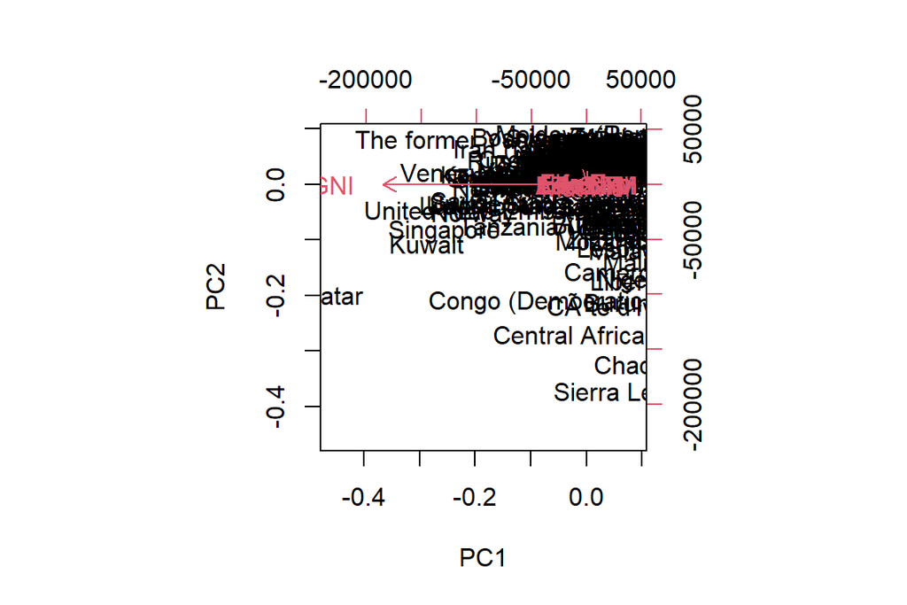

```r
biplot(pca_human, choices = 1:2)
```

PC1 explains 99.99% variability of the data and PC2 only 0.01%.

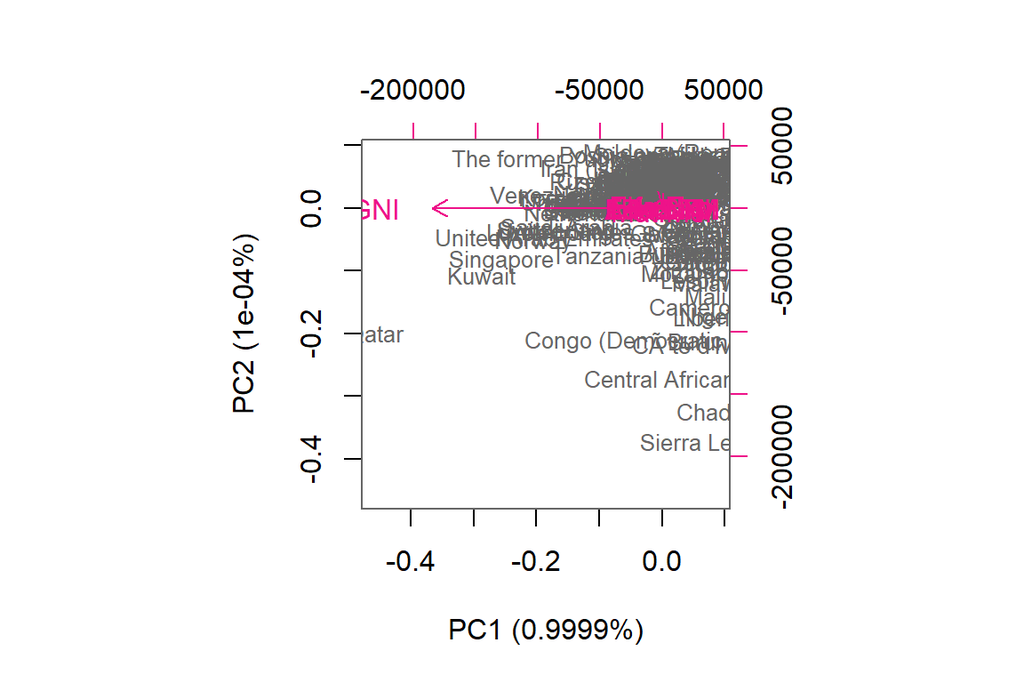

```r
# Biplot
pc_lab <- paste0(names(pca_pr), " (", pca_pr, "%)")

biplot(pca_human, cex = c(0.8, 1), col = c("grey40", "deeppink2"), xlab = pc_lab[1], ylab = pc_lab[2])
```

### PCA on standardized data

```r
# standardize the variables
human_std <- scale(human)

spca_human <- prcomp(human_std)

ss <- summary(spca_human)
ss
```

```
## Importance of components:
##                           PC1    PC2     PC3     PC4     PC5     PC6     PC7
## Standard deviation     2.0708 1.1397 0.87505 0.77886 0.66196 0.53631 0.45900
## Proportion of Variance 0.5361 0.1624 0.09571 0.07583 0.05477 0.03595 0.02634
## Cumulative Proportion  0.5361 0.6984 0.79413 0.86996 0.92473 0.96069 0.98702
##                            PC8
## Standard deviation     0.32224
## Proportion of Variance 0.01298
## Cumulative Proportion  1.00000
```

```r
# Variability captured by the principal components
spca_pr <- round(100*ss$importance[2, ], digits = 1)
spca_pr
```

```
##  PC1  PC2  PC3  PC4  PC5  PC6  PC7  PC8
## 53.6 16.2  9.6  7.6  5.5  3.6  2.6  1.3
```

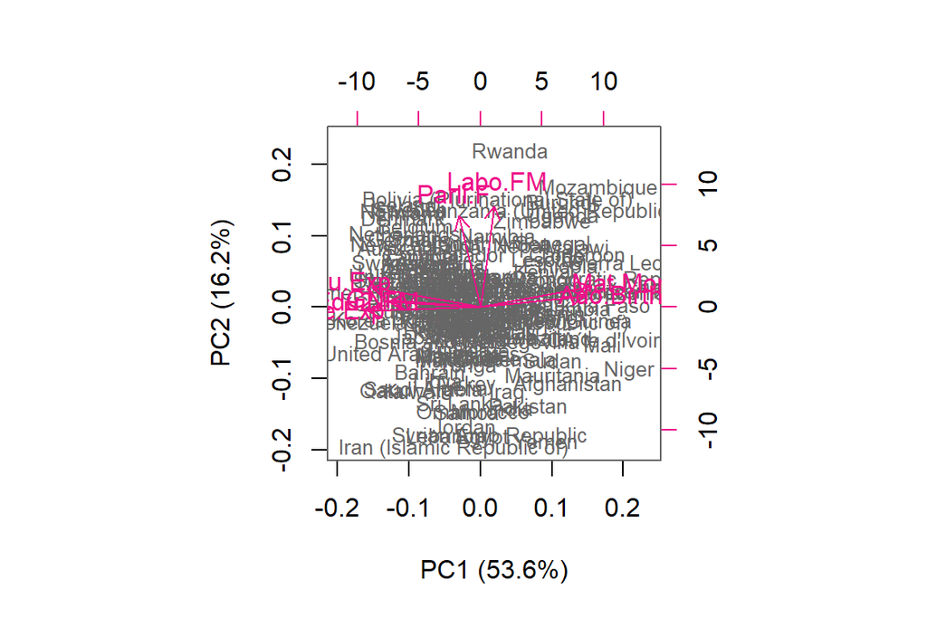

```r
# Biplot
pc_lab <- paste0(names(spca_pr), " (", spca_pr, "%)")

biplot(spca_human, cex = c(0.8, 1), col = c("grey40", "deeppink2"), xlab = pc_lab[1], ylab = pc_lab[2])
```

PC1 accounts for more than half of the variability of the data (53.6%). Compared to un-standardized data, all the components now contribute to the variability.

In the new biplot, the variables have scattered much more. Also, there are more variable names visible.

### Interpretation:

Countries are scattered all over the factor map. For example, Rwanda is the furthest away from PC1, thus, it represents PC2 well.

```r
tea <- read.csv("https://raw.githubusercontent.com/KimmoVehkalahti/Helsinki-Open-Data-Science/master/datasets/tea.csv", stringsAsFactors = TRUE)

View(tea)
str(tea)
```

```
## 'data.frame':    300 obs. of  36 variables:
##  $ breakfast       : Factor w/ 2 levels "breakfast","Not.breakfast": 1 1 2 2 1 2 1 2 1 1 ...
##  $ tea.time        : Factor w/ 2 levels "Not.tea time",..: 1 1 2 1 1 1 2 2 2 1 ...
##  $ evening         : Factor w/ 2 levels "evening","Not.evening": 2 2 1 2 1 2 2 1 2 1 ...
##  $ lunch           : Factor w/ 2 levels "lunch","Not.lunch": 2 2 2 2 2 2 2 2 2 2 ...
##  $ dinner          : Factor w/ 2 levels "dinner","Not.dinner": 2 2 1 1 2 1 2 2 2 2 ...
##  $ always          : Factor w/ 2 levels "always","Not.always": 2 2 2 2 1 2 2 2 2 2 ...
##  $ home            : Factor w/ 2 levels "home","Not.home": 1 1 1 1 1 1 1 1 1 1 ...
##  $ work            : Factor w/ 2 levels "Not.work","work": 1 1 2 1 1 1 1 1 1 1 ...
##  $ tearoom         : Factor w/ 2 levels "Not.tearoom",..: 1 1 1 1 1 1 1 1 1 2 ...
##  $ friends         : Factor w/ 2 levels "friends","Not.friends": 2 2 1 2 2 2 1 2 2 2 ...
##  $ resto           : Factor w/ 2 levels "Not.resto","resto": 1 1 2 1 1 1 1 1 1 1 ...
##  $ pub             : Factor w/ 2 levels "Not.pub","pub": 1 1 1 1 1 1 1 1 1 1 ...
##  $ Tea             : Factor w/ 3 levels "black","Earl Grey",..: 1 1 2 2 2 2 2 1 2 1 ...
##  $ How             : Factor w/ 4 levels "alone","lemon",..: 1 3 1 1 1 1 1 3 3 1 ...
```

[output cut: 22 more lines]

```r
dim(tea)
```

```
## [1] 300  36
```

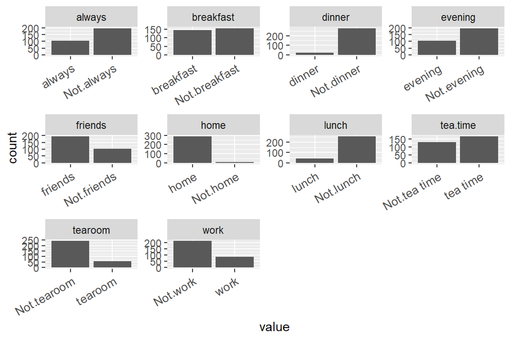

```r
library(dplyr)
library(tidyr)
library(ggplot2)


### change which variable to see (tea[1:10]) <--- for example
gather(tea[1:10]) %>% ggplot(aes(value)) + facet_wrap("key", scales = "free")  + geom_bar() + theme(axis.text.x = element_text(angle = 30, hjust = 1, size = 10))
```

### MCA with tea dataset

```r
library(FactoMineR)

keep_tea <- c("Tea", "How", "sugar", "where")

k_tea <- select(tea, one_of(keep_tea))
dim(k_tea)
```

```
## [1] 300   4
```

```r
mca <- MCA(k_tea, graph = FALSE)
summary(mca)
```

```
##
## Call:
## MCA(X = k_tea, graph = FALSE)
##
##
## Eigenvalues
##                        Dim.1   Dim.2   Dim.3   Dim.4   Dim.5   Dim.6   Dim.7
## Variance               0.334   0.326   0.299   0.252   0.229   0.219   0.186
## % of var.             16.724  16.282  14.947  12.617  11.439  10.935   9.276
## Cumulative % of var.  16.724  33.006  47.953  60.570  72.010  82.945  92.221
##                        Dim.8
## Variance               0.156
## % of var.              7.779
## Cumulative % of var. 100.000
##
## Individuals (the 10 first)
##                Dim.1    ctr   cos2    Dim.2    ctr   cos2    Dim.3    ctr
## 1           | -0.034  0.001  0.001 |  0.200  0.041  0.031 | -0.337  0.127
## 2           |  0.387  0.149  0.072 |  0.664  0.451  0.212 | -0.442  0.218
## 3           | -0.304  0.092  0.143 |  0.145  0.021  0.032 | -0.331  0.122
## 4           | -0.398  0.158  0.232 | -0.475  0.231  0.332 | -0.345  0.133
## 5           | -0.304  0.092  0.143 |  0.145  0.021  0.032 | -0.331  0.122
## 6           | -0.304  0.092  0.143 |  0.145  0.021  0.032 | -0.331  0.122
## 7           | -0.304  0.092  0.143 |  0.145  0.021  0.032 | -0.331  0.122
## 8           |  0.387  0.149  0.072 |  0.664  0.451  0.212 | -0.442  0.218
## 9           |  0.669  0.446  0.221 | -0.136  0.019  0.009 | -0.113  0.014
## 10          |  0.706  0.497  0.270 |  0.695  0.494  0.262 |  0.013  0.000
##               cos2
## 1            0.087 |
## 2            0.094 |
## 3            0.169 |
## 4            0.175 |
## 5            0.169 |
## 6            0.169 |
## 7            0.169 |
## 8            0.094 |
## 9            0.006 |
## 10           0.000 |
##
## Categories (the 10 first)
```

[output cut: 14 more lines]

```
## green       |   0.884   7.194   0.097   5.376 |
## alone       |  -0.164   1.467   0.050  -3.871 |
## lemon       |   1.879  32.467   0.436  11.421 |
## milk        |  -0.424   3.156   0.048  -3.780 |
## other       |  -0.362   0.328   0.004  -1.100 |
## No.sugar    |   0.015   0.009   0.000   0.262 |
## sugar       |  -0.016   0.010   0.000  -0.262 |
## chain store |  -0.460  11.342   0.377 -10.613 |
##
## Categorical variables (eta2)
##               Dim.1 Dim.2 Dim.3
## Tea         | 0.355 0.548 0.097 |
## How         | 0.511 0.197 0.447 |
## sugar       | 0.012 0.500 0.000 |
## where       | 0.460 0.058 0.651 |
```

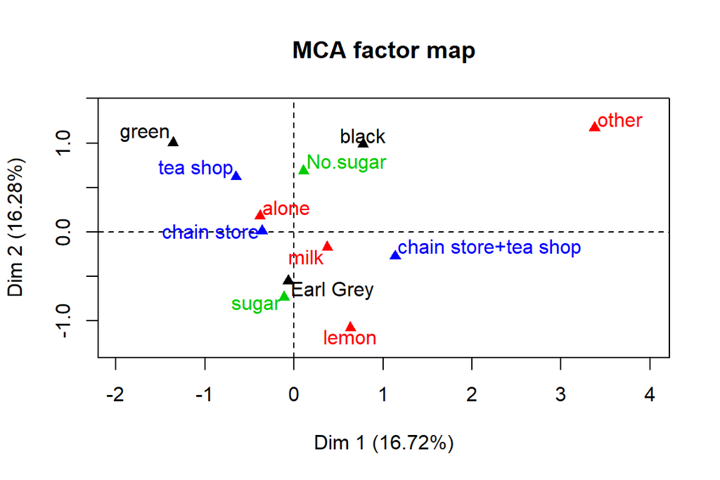

```r
# visualize MCA
plot(mca, invisible=c("ind"), graph.type = "classic", habillage = "quali")
```

Only ~33% of variance is explained by first two data sets. Should likely be advisable to include more variables.

# Analysis of longitudial data

## RATS DATA

```r
library(tidyverse)

RATSL <- read.csv("RATSL.csv")


RATSL$ID <- factor(RATSL$ID)
RATSL$Group <- factor(RATSL$Group)
```

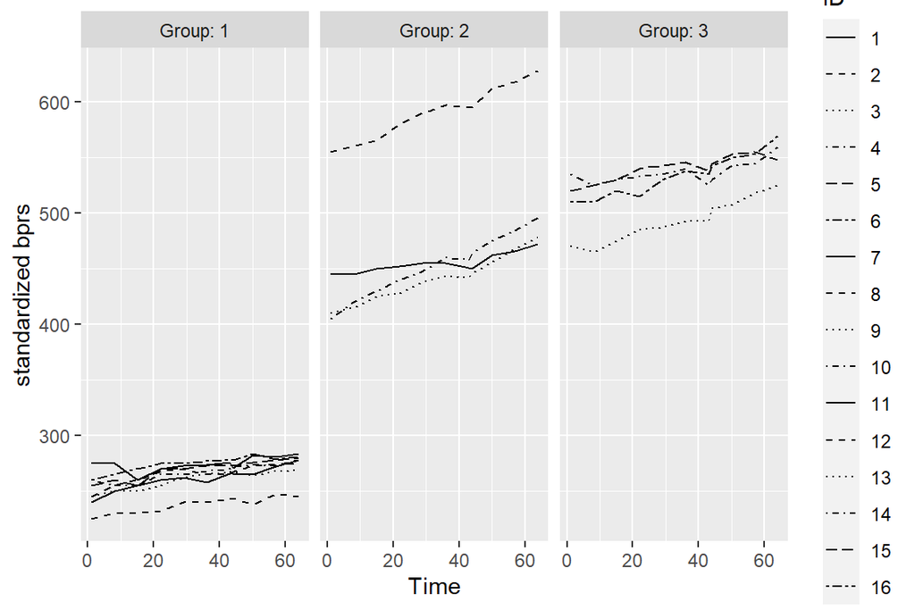

```r
library(ggplot2)

# Plot the RATSL data
ggplot(RATSL, aes(x = Time, y = Weight, linetype = ID)) +
  geom_line() +
  scale_linetype_manual(values = rep(1:10, times=4)) +
  facet_grid(. ~ Group, labeller = label_both) +
  scale_y_continuous(name = "standardized bprs")
```

After looking at the plots, it is evident that gropu 1 rats are lower weight than other groups. Also, group 3 rats seem heavier than rats in group 2, except for an outlier rat in group 2.

In all three groups, the rats have gained weight during the study (upward lines).

By standardizing the weight values, we may better analyze visually the weight gain pace of each group.
$$standardised(x) = \frac{x - mean(x)}{ sd(x)}$$

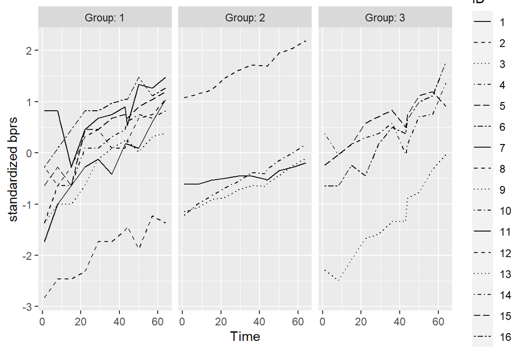

```r
# standardise RATSL data
RATSL <- RATSL %>%
  group_by(Group) %>%
  mutate(Weight_std = (Weight - mean(Weight))/sd(Weight)) %>%
  ungroup()

# plot standardized weights
ggplot(RATSL, aes(x = Time, y = Weight_std, linetype = ID)) +
  geom_line() +
  scale_linetype_manual(values = rep(1:10, times=4)) +
  facet_grid(. ~ Group, labeller = label_both) +
  scale_y_continuous(name = "standardized bprs")
```

Weight gain seems faster in groups 1 & 3 (steeper line angle). Also, there seems to be one rather distinct outlier in each group.

```r
# Summary data with mean and standard error of bprs by treatment and week
RATSLS <- RATSL %>%
  group_by(Group, Time) %>%
  summarise( mean = mean(Weight), se = sd(Weight)  ) %>%
  ungroup()
# Glimpse the data
glimpse(RATSLS)
```

```
## Rows: 33
## Columns: 4
## $ Group <fct> 1, 1, 1, 1, 1, 1, 1, 1, 1, 1, 1, 2, 2, 2, 2, 2, 2, 2, 2, 2, 2, 2~
## $ Time  <int> 1, 8, 15, 22, 29, 36, 43, 44, 50, 57, 64, 1, 8, 15, 22, 29, 36, ~
## $ mean  <dbl> 250.625, 255.000, 254.375, 261.875, 264.625, 265.000, 267.375, 2~
## $ se    <dbl> 15.22158, 13.09307, 11.47591, 13.60081, 11.05748, 11.78377, 10.9~
```

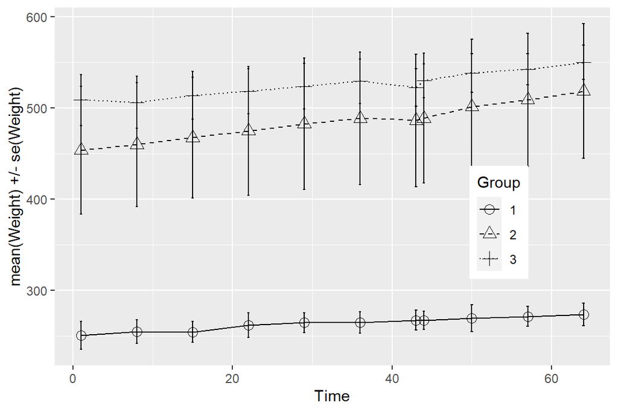

```r
# Plot the mean profiles
ggplot(RATSLS, aes(x = Time, y = mean, linetype = Group, shape = Group)) +
  geom_line() +
  scale_linetype_manual(values = c(1,2,3)) +
  geom_point(size=3) +
  scale_shape_manual(values = c(1,2,3)) +
  geom_errorbar(aes(ymin=mean - se, ymax= mean + se, linetype="1"), width=0.3) +
  theme(legend.position = c(0.8,0.4)) +
  scale_y_continuous(name = "mean(Weight) +/- se(Weight)")
```

Group 3 is on average the heaviest. Also, it seems slightly that group 2 has the fastest weight gain on average.

```r
RATSL2 <- RATSL %>%
#  filter(Time > 0) %>%
  group_by(Group, ID) %>%
  summarise( mean=mean(Weight) ) %>%
  ungroup()
# Glimpse the data
glimpse(RATSL2)
```

```
## Rows: 16
## Columns: 3
## $ Group <fct> 1, 1, 1, 1, 1, 1, 1, 1, 2, 2, 2, 2, 3, 3, 3, 3
## $ ID    <fct> 1, 2, 3, 4, 5, 6, 7, 8, 9, 10, 11, 12, 13, 14, 15, 16
## $ mean  <dbl> 261.0909, 237.6364, 260.1818, 266.5455, 269.4545, 274.7273, 274.~
```

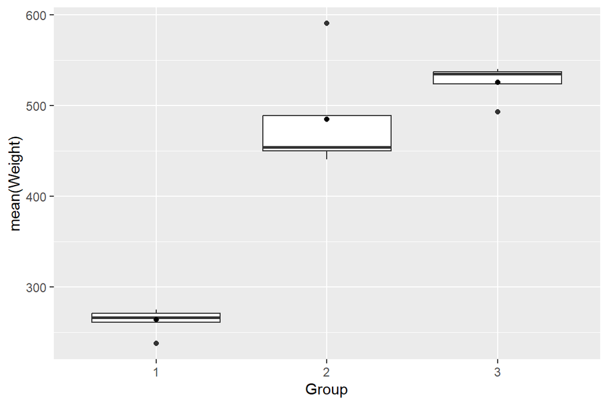

```r
# Draw a boxplot of the mean versus treatment
ggplot(RATSL2, aes(x = Group, y = mean)) +
  geom_boxplot() +
  stat_summary(fun = "mean", geom = "point", fill = "white") +
  scale_y_continuous(name = "mean(Weight)")
```

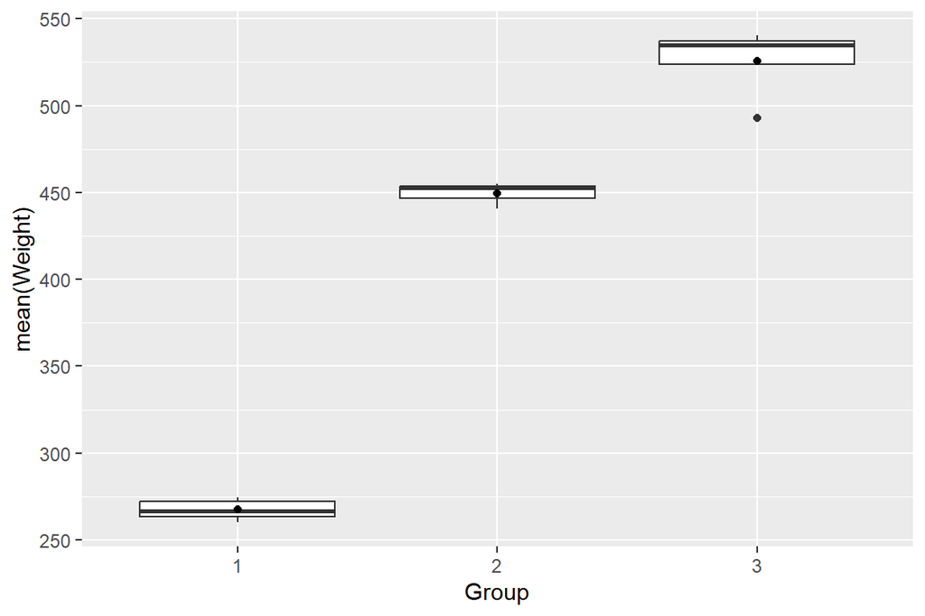

```r
# Remove outliers
RATSL21 <- RATSL2 %>%
  filter(mean < 550 & mean > 240 )

ggplot(RATSL21, aes(x = Group, y = mean)) +
  geom_boxplot() +
  stat_summary(fun = "mean", geom = "point", fill = "white") +
  scale_y_continuous(name = "mean(Weight)")
```

```r
min(RATSL21$mean)
```

```
## [1] 260.1818
```

It seems that outlier especially in group 2 has an affect on the results.

```r
# Perform a two-sample t-test
# Make group lists
groups <- list()
for(i in 1:3) groups[[i]] <- RATSL21$mean[which(RATSL21$Group == i)]

# 1 vs. 2
t.test(groups[[1]], groups[[2]])
```

```
##
##  Welch Two Sample t-test
##
## data:  groups[[1]] and groups[[2]]
## t = -37.206, df = 3.1002, p-value = 3.259e-05
## alternative hypothesis: true difference in means is not equal to 0
## 95 percent confidence interval:
##  -197.3009 -166.7251
## sample estimates:
## mean of x mean of y
##  267.4416  449.4545
```

```r
# 1 vs. 3
t.test(groups[[1]], groups[[3]])
```

```
##
##  Welch Two Sample t-test
##
## data:  groups[[1]] and groups[[3]]
## t = -22.943, df = 3.2445, p-value = 0.0001058
## alternative hypothesis: true difference in means is not equal to 0
## 95 percent confidence interval:
##  -292.7105 -223.9973
## sample estimates:
## mean of x mean of y
##  267.4416  525.7955
```

```r
# 2 vs. 3
t.test(groups[[2]], groups[[3]])
```

```
##
##  Welch Two Sample t-test
##
## data:  groups[[2]] and groups[[3]]
## t = -6.4314, df = 3.8677, p-value = 0.003371
## alternative hypothesis: true difference in means is not equal to 0
## 95 percent confidence interval:
##  -109.74659  -42.93523
## sample estimates:
## mean of x mean of y
##  449.4545  525.7955
```

As notified earlier, there are clear differences between groups mean weights. Additionally, t-test reveals that the differences are statistically significant.

## BPRS DATA

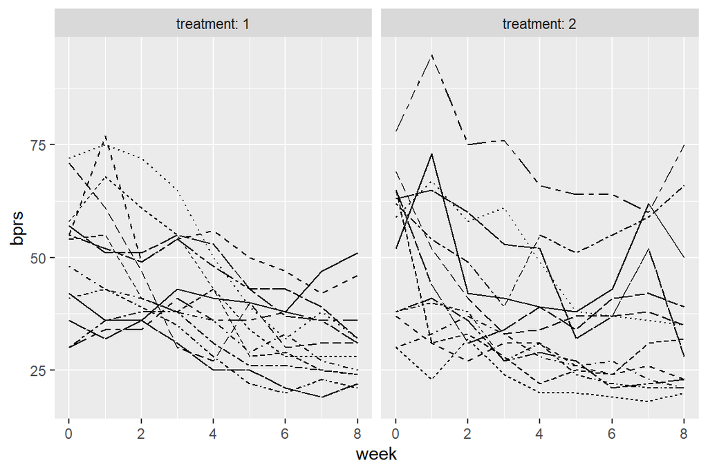

```r
# Load data

BPRSL <- read.csv("BPRSL.csv")

# Factor treatment & subject
BPRSL$treatment <- factor(BPRSL$treatment)
BPRSL$subject <- factor(BPRSL$subject)
# Convert to long form
# BPRSL <-  pivot_longer(BPRS, cols = -c(treatment, subject),
#                       names_to = "weeks", values_to = "bprs") %>%
#  arrange(weeks)

# Extract the week number
BPRSL <-  BPRSL %>%
  mutate(week = as.integer(substr(weeks, 5, 5)))

# Plot data
ggplot(BPRSL, aes(x = week, y = bprs, linetype = subject)) +
  geom_line() +
  facet_grid(. ~ treatment, labeller = label_both) +
  theme(legend.position = "none")
```

In both treatment groups there seems to me a general decreasing trend in BPRS. Subjects in the first group however seem more identical because there is less variance between subjects.

```r
# Create linear regression model
BPRS_reg <- lm(bprs ~ week + treatment, data=BPRSL)

summary(BPRS_reg)
```

```
##
## Call:
## lm(formula = bprs ~ week + treatment, data = BPRSL)
##
## Residuals:
##     Min      1Q  Median      3Q     Max
## -22.454  -8.965  -3.196   7.002  50.244
##
## Coefficients:
##             Estimate Std. Error t value Pr(>|t|)
## (Intercept)  46.4539     1.3670  33.982   <2e-16 ***
## week         -2.2704     0.2524  -8.995   <2e-16 ***
## treatment2    0.5722     1.3034   0.439    0.661
## ---
## Signif. codes:  0 '***' 0.001 '**' 0.01 '*' 0.05 '.' 0.1 ' ' 1
##
## Residual standard error: 12.37 on 357 degrees of freedom
## Multiple R-squared:  0.1851, Adjusted R-squared:  0.1806
## F-statistic: 40.55 on 2 and 357 DF,  p-value: < 2.2e-16
```

The regression model results show that there is a statistically significant relationship with variable week (expressing duration) and BPRS. Moreover, the decrease by week is on average ~2.3 points. However, no statistical significance between treatments.

```r
library(lme4)
str(BPRSL)
```

```
## 'data.frame':    360 obs. of  5 variables:
##  $ treatment: Factor w/ 2 levels "1","2": 1 1 1 1 1 1 1 1 1 1 ...
##  $ subject  : Factor w/ 20 levels "1","2","3","4",..: 1 2 3 4 5 6 7 8 9 10 ...
##  $ weeks    : chr  "week0" "week0" "week0" "week0" ...
##  $ bprs     : int  42 58 54 55 72 48 71 30 41 57 ...
##  $ week     : int  0 0 0 0 0 0 0 0 0 0 ...
```

```r
BPRS_lme <- lmer(bprs ~ week + treatment + (1 | subject), data = BPRSL, REML = FALSE)
summary(BPRS_lme)
```

```
## Linear mixed model fit by maximum likelihood  ['lmerMod']
## Formula: bprs ~ week + treatment + (1 | subject)
##    Data: BPRSL
##
##      AIC      BIC   logLik deviance df.resid
##   2748.7   2768.1  -1369.4   2738.7      355
##
## Scaled residuals:
##     Min      1Q  Median      3Q     Max
## -3.0481 -0.6749 -0.1361  0.4813  3.4855
##
## Random effects:
##  Groups   Name        Variance Std.Dev.
##  subject  (Intercept)  47.41    6.885
##  Residual             104.21   10.208
## Number of obs: 360, groups:  subject, 20
##
## Fixed effects:
##             Estimate Std. Error t value
## (Intercept)  46.4539     1.9090  24.334
## week         -2.2704     0.2084 -10.896
## treatment2    0.5722     1.0761   0.532
##
## Correlation of Fixed Effects:
##            (Intr) week
## week       -0.437
## treatment2 -0.282  0.000
```

```r
# create a random intercept and random slope model

BPRS_lme2 <- lmer(bprs ~ week + treatment + (week | subject), data = BPRSL, REML = FALSE)
summary(BPRS_lme2)
```

```
## Linear mixed model fit by maximum likelihood  ['lmerMod']
## Formula: bprs ~ week + treatment + (week | subject)
##    Data: BPRSL
##
##      AIC      BIC   logLik deviance df.resid
##   2745.4   2772.6  -1365.7   2731.4      353
##
## Scaled residuals:
##     Min      1Q  Median      3Q     Max
## -2.8919 -0.6194 -0.0691  0.5531  3.7976
##
## Random effects:
##  Groups   Name        Variance Std.Dev. Corr
##  subject  (Intercept) 64.8222  8.0512
##           week         0.9609  0.9802   -0.51
##  Residual             97.4305  9.8707
## Number of obs: 360, groups:  subject, 20
##
## Fixed effects:
##             Estimate Std. Error t value
## (Intercept)  46.4539     2.1052  22.066
## week         -2.2704     0.2977  -7.626
## treatment2    0.5722     1.0405   0.550
##
## Correlation of Fixed Effects:
##            (Intr) week
## week       -0.582
## treatment2 -0.247  0.000
```

No major differences between the two models.

```r
anova(BPRS_lme, BPRS_lme2)
```

```
## Data: BPRSL
## Models:
## BPRS_lme: bprs ~ week + treatment + (1 | subject)
## BPRS_lme2: bprs ~ week + treatment + (week | subject)
##           npar    AIC    BIC  logLik deviance  Chisq Df Pr(>Chisq)
## BPRS_lme     5 2748.7 2768.1 -1369.4   2738.7
## BPRS_lme2    7 2745.4 2772.6 -1365.7   2731.4 7.2721  2    0.02636 *
## ---
## Signif. codes:  0 '***' 0.001 '**' 0.01 '*' 0.05 '.' 0.1 ' ' 1
```

```r
# Create a random intercept and slope model for a group × time interaction.
BPRS_lme3 <- lmer(bprs ~ week + treatment + (week | subject) + week * treatment, data = BPRSL, REML = FALSE)
summary(BPRS_lme3)
```

```
## Linear mixed model fit by maximum likelihood  ['lmerMod']
## Formula: bprs ~ week + treatment + (week | subject) + week * treatment
##    Data: BPRSL
##
##      AIC      BIC   logLik deviance df.resid
##   2744.3   2775.4  -1364.1   2728.3      352
##
## Scaled residuals:
##     Min      1Q  Median      3Q     Max
## -3.0512 -0.6271 -0.0768  0.5288  3.9260
##
## Random effects:
##  Groups   Name        Variance Std.Dev. Corr
##  subject  (Intercept) 64.9964  8.0620
##           week         0.9687  0.9842   -0.51
##  Residual             96.4707  9.8220
## Number of obs: 360, groups:  subject, 20
##
## Fixed effects:
##                 Estimate Std. Error t value
## (Intercept)      47.8856     2.2521  21.262
## week             -2.6283     0.3589  -7.323
## treatment2       -2.2911     1.9090  -1.200
## week:treatment2   0.7158     0.4010   1.785
##
## Correlation of Fixed Effects:
##             (Intr) week   trtmn2
## week        -0.650
## treatment2  -0.424  0.469
## wek:trtmnt2  0.356 -0.559 -0.840
```

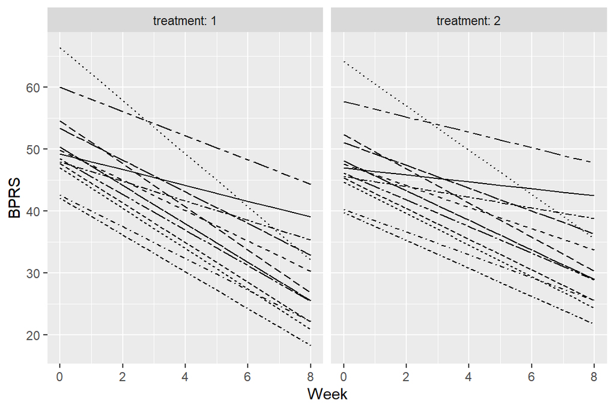

```r
# Create data with fitted valus

BPRSL_fit <- BPRSL
BPRSL_fit$bprs <- predict(BPRS_lme3)


ggplot(BPRSL_fit) +
  geom_line(aes(x = week, y = bprs, linetype = subject)) +
  scale_x_continuous(name = "Week") +
  scale_y_continuous(name = "BPRS") +
  theme(legend.position = "top") +
  facet_grid(. ~treatment, labeller=label_both) +
  theme(legend.position = "none")
```

Above is the plotted fitted model for both treatments.